# Cardiovascular model in Section 5 | Real data

This notebook contains the code of the paper "Learning Physics between Digital Twins with Low-Fidelity Models and Physics-Informed Gaussian Processes". The models are fitted in rstan and the code is available in the folder "STAN/WK2_periodic".

#### Load packages

```r
# uncomment to install
# install.packages("rstan")
# install.packages("ggplot2")
# install.packages("latex2exp")
library(rstan)
library(ggplot2)
library(latex2exp)
rstan_options(auto_write = TRUE)
options(mc.cores = 3) # allocate 3 cores (for each model we run 3 chains in parallel)
```

#### Data

We use real data from 8 individuals obtained by clinical trial.

```r
data_trial = readRDS("Data/data_trial.rds")
```

```r
nc=2
Ns=data_trial$Ns
yP=data_trial$yP
tP=data_trial$tP
yI=data_trial$yI
tI=data_trial$tI
nP=data_trial$nP
nI=data_trial$nI
ID = paste0("ID = ", 1:Ns)
df_Pobs = data.frame(pressure = as.vector(t(yP)), time = as.vector(t(tP)), ID = rep(ID, each=nP))
df_Qobs = data.frame(inflow = as.vector(t(yI)), time = as.vector(t(tI)), ID = rep(ID, each=nI))

# ggplot()+
#   geom_point(data=df_Pobs, aes(x=time,y=pressure), color="black", size=0.5)+
#   facet_wrap(ID~., nrow = 2)+theme_bw()+xlab("time (sec)")+ ylab("pressure (mmHg)")
#
# ggplot()+
#   geom_point(data=df_Qobs, aes(x=time,y=inflow), color="black", size=0.5)+
#   facet_wrap(ID~., nrow = 2)+theme_bw()+xlab("time (sec)")+ ylab("inflow (ml/min)")
```

```r
ind_4 = df_Pobs$ID %in% c("ID = 2","ID = 4","ID = 6","ID = 8")
# pl_P=ggplot()+
#   geom_point(data=df_Pobs[ind_4, ], aes(x=time,y=pressure), color="black", size=0.5)+
#   facet_wrap(ID~., nrow = 1)+theme_bw()+xlab("time (sec)")+ ylab("pressure (mmHg)")+
#   theme(axis.title = element_text(size = 16))
# pl_P
# ggsave("Figs/P_trial.pdf", plot = pl_P, width = 20, height = 7, units = "cm")
```

### Model 1 (no-without $\delta(t)$ in paper, Figure 9)

Stan code:

```r
# writeLines(readLines('STAN/WK2_periodic/WK2_per_nodelta.stan'))
```

```r
post_nnd=post_nwd=l_df_nnd=l_df_nwd=list()
```

We fit the model to each individual data set and we plot the trace for the last individual

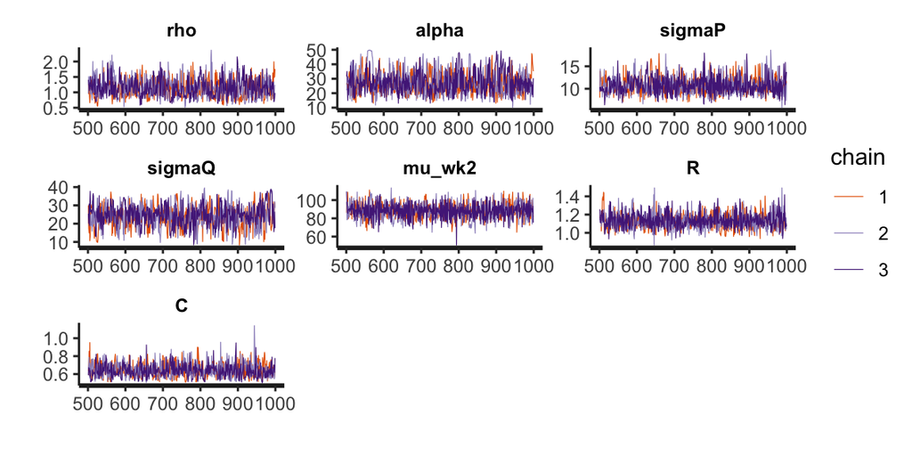

```r
#-------------------------------------------------
# WK2 PI prior / no delta (magenta model)
for(i in 1:Ns){
  data_ind = list(nP=nP, nI=nI, tP=matrix(tP[i,],ncol=1), tI=matrix(tI[i,],ncol=1), yP=yP[i,], yI=yI[i,], yDia=data_trial$yDia, p=data_trial$p[i])
  fit_nnd = stan(file= "STAN/WK2_periodic/WK2_per_nodelta.stan",
                  data=data_ind,
                  chains=3,
                  iter=1000,
                  seed=123
  )
  post_nnd[[i]]=extract(fit_nnd)
  l_df_nnd[[i]]=data.frame(extract(fit_nnd))
}
stan_trace(fit_nnd, size=0.2)
```

### Model 2 (no-with $\delta(t)$ in paper, Figure 9)

Now we account for model discrepancy $\delta_m(x_m)\sim GP(0,K_\delta(x_m,x_m')),$ where we use the squared exponential kernel $K_\delta(x_m,x_m') = \alpha_m^2 \exp\left(-\frac{(x_m-x_m')^2}{2\rho_m^2}\right).$ More details about the model are given in the Appendix E.1.

Stan code:

```r
# writeLines(readLines("STAN/WK2_periodic/WK2_delta_per.stan"))
```

We fit this model to each individual data set separately

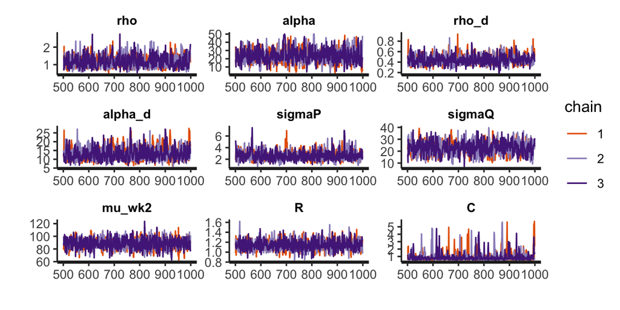

```r
# WK2 PI prior / with pressure delta (red model)
fit_smr=list()
for(i in 1:Ns){
  data_ind = list(nP=nP, nI=nI, tP=matrix(tP[i,],ncol=1), tI=matrix(tI[i,],ncol=1), yP=yP[i,], yI=yI[i,], yDia=data_trial$yDia, p=data_trial$p[i])
  fit_nwd = stan(file= "STAN/WK2_periodic/WK2_delta_per.stan",
                 data=data_ind,
                 chains=3,
                 iter=1000,
                 seed=123
  )
  fit_smr[[i]]=summary(fit_nwd)$summary
  post_nwd[[i]]=extract(fit_nwd)
  l_df_nwd[[i]]=data.frame(extract(fit_nwd))
}
stan_trace(fit_nwd)
```

### Model 3 (yes/common $\delta(t)$ in paper, Figure 9)

We allow individuals to share information about the physical parameters $u_m, m=1,2,\ldots,8$ through a global level parameter as described in Section 3.3. The model assumes same discrepancy parameters for all individuals.

Stan code:

```r
# writeLines(readLines("STAN/WK2_periodic/WK2_common_delta_per.stan"))
```

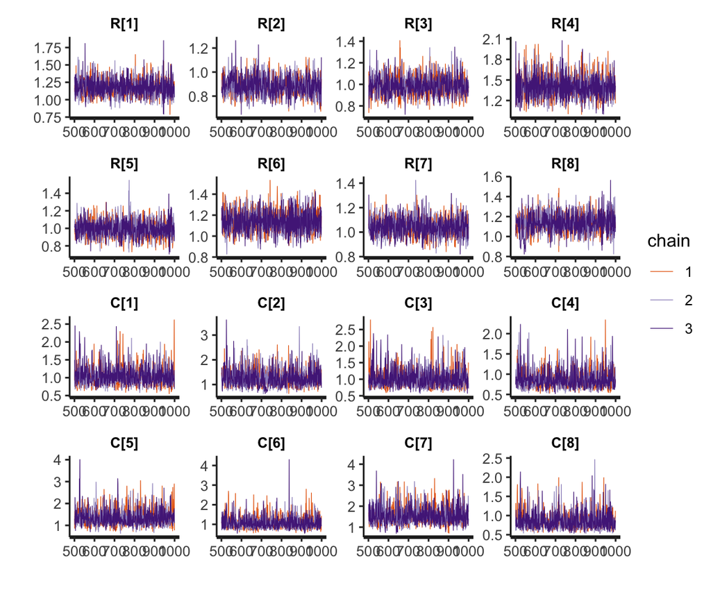

```r
#-------------------------------------------------
# shared R,C common delta (blue model)
fit_yes_common_delta = stan(file="STAN/WK2_periodic/WK2_common_delta_per.stan",
                            data=data_trial,
                            chains=3,
                            iter=1000,
                            seed=0
)
stan_trace(fit_yes_common_delta, pars = c("R","C"), size=0.2)
```

```r
ex_ycd=extract(fit_yes_common_delta)
df_ycd =data.frame(ex_ycd)
```

### Model 4 (yes/shared $\delta(t)$ in paper, Figure 9)

Stan code:

```r
# writeLines(readLines("STAN/WK2_periodic/WK2_shared_delta_per.stan"))
```

Model fit:

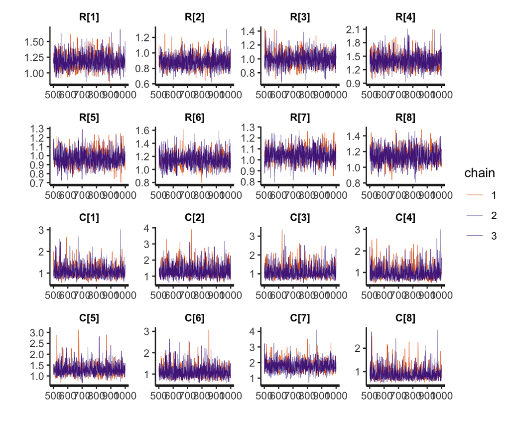

```r
# shared R,C shared delta (green model)
fit_ysd = stan(file="STAN/WK2_periodic/WK2_shared_delta_per.stan",
               data=data_trial,
               chains=3,
               iter=1000,
               seed=0
)
stan_trace(fit_ysd, pars = c("R", "C"), size=0.2)
```

```r
ex_ysd=extract(fit_ysd)
df_ysd=data.frame(ex_ysd)
```

#### Plot 95% CIs for all methods (Figure 9 in the paper)

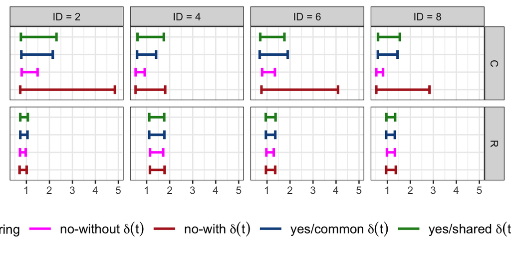

```r
ID = paste0("ID = ",1:8)
df_CIs$ID = rep(ID,8)
rid=df_CIs$id%in%c(2,4,6,8)
(pl_cis=ggplot()+
    geom_errorbar(data = df_CIs[rid,], aes(xmin=low, xmax=upper, y=sharing, color=sharing),size=1, width=0.5)+
    facet_grid(par~ID)+theme_bw()+ylab("")+xlim(0.5,5)+#xlab("ID")+
    scale_color_manual(
      breaks=c('no-without delta', 'no-with delta', "yes/common delta", "yes/shared delta"),
      values=c("magenta","firebrick","dodgerblue4", "forestgreen"),labels = lbl)+
  theme(
    axis.title.y=element_blank(),
    axis.text.y=element_blank(),
    axis.ticks.y=element_blank(),
    legend.position="bottom",
    legend.key.size = unit(0.8, 'cm'), #change legend key size
    legend.key.height = unit(0.8, 'cm'), #change legend key height
    legend.key.width = unit(0.8, 'cm'), #change legend key width
    legend.title = element_text(size=11), #change legend title font size
    legend.text = element_text(size=11),
    axis.title.x = element_text(size=11))
  )
```

```r
# ggsave("Figs/wk_trial_cis_new.pdf", plot = pl_cis, width = 17, height = 8.5, units = "cm")
```

#### Uncertainty reduction

```r
df_red=df_CIs[df_CIs$sharing == "no-with delta" | df_CIs$sharing == "yes/common delta" | df_CIs$sharing == "yes/shared delta",]
df_red_C = df_red[df_red$par=="C",]
df_red_C$dif = df_red_C$upper-df_red_C$low

methd=c("no-with delta", "yes/common delta",  "yes/shared delta")
red_common = (df_red_C$dif[df_red_C$sharing == methd[1]] - df_red_C$dif[df_red_C$sharing == methd[2]])/ df_red_C$dif[df_red_C$sharing == methd[1]]
red_shared = (df_red_C$dif[df_red_C$sharing == methd[1]] - df_red_C$dif[df_red_C$sharing == methd[3]])/ df_red_C$dif[df_red_C$sharing == methd[1]]
mu_lu_fn = function(df) c(mu = mean(df), lower=min(df), upper=max(df))
# mu_lu_fn(red_common)
# mu_lu_fn(red_shared)
res_C = data.frame(common = as.vector(mu_lu_fn(red_common)), shared = as.vector(mu_lu_fn(red_shared)))
rownames(res_C) = c("mean", "low", "upper")

df_red_R = df_red[df_red$par=="R",]
df_red_R$dif = df_red_R$upper-df_red_R$low

red_common = (df_red_R$dif[df_red_R$sharing == methd[1]] - df_red_R$dif[df_red_R$sharing == methd[2]])/ df_red_R$dif[df_red_R$sharing == methd[1]]
red_shared = (df_red_R$dif[df_red_R$sharing == methd[1]] - df_red_R$dif[df_red_R$sharing == methd[3]])/ df_red_R$dif[df_red_R$sharing == methd[1]]
mu_lu_fn = function(df) c(mu = mean(df), lower=min(df), upper=max(df))
# mu_lu_fn(red_common)
# mu_lu_fn(red_shared)
res_R = data.frame(common = as.vector(mu_lu_fn(red_common)), shared = as.vector(mu_lu_fn(red_shared)))
rownames(res_R) = c("mean", "low", "upper")
res_RC = list(R=res_R, C=res_C)
# saveRDS(res_RC, file = "Data/reduction_WK_trial.rds")
round(res_RC$R[1,],2)
```

|  | common | shared |
| --- | --- | --- |
| mean | -0.01 | 0.01 |

```r
round(res_RC$C[1,],2)
```

|  | common | shared |
| --- | --- | --- |
| mean | 0.6 | 0.59 |